# NCAA Stats to NBA Success

Dylan DeJean

5/4/2021

## Loading the Data

```r
library(mosaic)
library(tidyverse)
```

Primary data set:

```r
NCAAtoNBA <- read.csv("https://query.data.world/s/ka2bzbvk4ygt3hlhg5pf5yd5j532ew", header=TRUE, stringsAsFactors=FALSE);
```

This is a data set that contains all NBA players from 1947 to 2018 and their NBA stats as well as their stats from their time in the NCAA.

This data set came from data.world and was made by scraping https://www.basketball-reference.com/ and https://www.sports-reference.com/cbb to create a table with each players stats from their college and professional careers. The link to the data.world page is https://data.world/bgp12/nbancaacomparisons.

Supplemental data sets:

```r
Players <- read.csv("https://query.data.world/s/caexob6wcclzrb6uej2xlkmkjispjs", header=TRUE, stringsAsFactors=FALSE);
Salaries <- read.csv("https://query.data.world/s/rdwgdzrlnvdnymyenioxifr5mnh4iv", header=TRUE, stringsAsFactors=FALSE);
```

## Research Question

The question I would like to explore with this data is what player stats from NCAA careers contribute the most to their average salaries throughout their NBA career? Do NBA player statistics have larger effects on average salaries than NCAA statistics? If so, by how much? I would also like to see how much the round in which the players were drafted contributes to their average salaries.

## Looking at the Data

```r
glimpse(NCAAtoNBA)
```

```
Rows: 4,576
Columns: 34
$ X                <int> 0, 1, 2, 3, 4, 5, 6, 7, 8, 9, 10, 11, 12, 13, 14, 15, 16, 17, 18, 19, 20,...
$ active_from      <int> 1991, 1969, 1970, 1991, 1998, 1997, 1977, 1957, 1947, 2017, 2006, 1954, 1...
$ active_to        <int> 1995, 1978, 1989, 2001, 2003, 2008, 1981, 1957, 1948, 2018, 2009, 1954, 1...
$ birth_date       <chr> "June 24, 1968", "April 7, 1946", "April 16, 1947", "March 9, 1969", "Nov...
$ college          <chr> "Duke University", "Iowa State University", "University of California, Lo...
$ height           <chr> "6-10", "6-9", "7-2", "6-1", "6-6", "6-9", "6-7", "6-3", "6-3", "6-6", "6...
$ name             <chr> "Alaa Abdelnaby", "Zaid Abdul-Aziz", "Kareem Abdul-Jabbar", "Mahmoud Abdu...
$ position         <chr> "F-C", "C-F", "C", "G", "F", "F", "F", "G", "F", "G-F", "G", "G", "F-C", ...
$ url              <chr> "/players/a/abdelal01.html", "/players/a/abdulza01.html", "/players/a/abd...
$ weight           <int> 240, 235, 225, 162, 223, 225, 220, 180, 195, 190, 185, 183, 220, 210, 240...
$ NBA__3ptapg      <dbl> 0.0, NA, 0.0, 2.3, 0.3, 0.6, 0.0, NA, NA, 3.3, 0.8, NA, 0.0, NA, 1.5, 0.0...
$ NBA__3ptpct      <dbl> 0.000, NA, 0.056, 0.354, 0.237, 0.297, 0.000, NA, NA, 0.379, 0.320, NA, 0...
$ NBA__3ptpg       <dbl> 0.0, NA, 0.0, 0.8, 0.1, 0.2, 0.0, NA, NA, 1.2, 0.3, NA, 0.0, NA, 0.5, 0.0...
```

[output cut: 21 more lines]

Here we see a lot of different statistics for each player throughout their careers. I think the most important stats to look at here would be points per game in the NBA and NCAA as well as the field goal percentage for each league as well.

```r
glimpse(Salaries)
```

```
Rows: 14,163
Columns: 7
$ league       <chr> "NBA", "NBA", "NBA", "NBA", "NBA", "NBA", "NBA", "NBA", "NBA", "NBA", "NBA", ...
$ player_id    <chr> "abdelal01", "abdelal01", "abdelal01", "abdelal01", "abdelal01", "abdulka01",...
$ salary       <int> 395000, 494000, 500000, 805000, 650000, 1530000, 2030000, 2000000, 3000000, 1...
$ season       <chr> "1990-91", "1991-92", "1992-93", "1993-94", "1994-95", "1984-85", "1985-86", ...
$ season_end   <int> 1991, 1992, 1993, 1994, 1995, 1985, 1986, 1988, 1989, 1991, 1992, 1993, 1994,...
$ season_start <int> 1990, 1991, 1992, 1993, 1994, 1984, 1985, 1987, 1988, 1990, 1991, 1992, 1993,...
$ team         <chr> "Portland Trail Blazers", "Portland Trail Blazers", "Boston Celtics", "Boston...
```

```r
glimpse(Players)
```

```
Rows: 4,685
Columns: 24
$ X_id        <chr> "abdelal01", "abdulza01", "abdulka01", "abdulma02", "abdulta01", "abdursh01", ...
$ birthDate   <chr> "June 24, 1968", "April 7, 1946", "April 16, 1947", "March 9, 1969", "November...
$ birthPlace  <chr> "Cairo, Egypt", "Brooklyn, New York", "New York, New York", "Gulfport, Mississ...
$ career_AST  <dbl> 0.3, 1.2, 3.6, 3.5, 1.1, 2.5, 1.2, 1.0, 0.7, 0.5, 0.5, 0.8, 0.5, 0.5, 0.6, 4.1...
$ career_FG.  <chr> "50.2", "42.8", "55.9", "44.2", "41.7", "47.2", "49.2", "0.0", "23.7", "38.7",...
$ career_FG3. <chr> "0.0", "", "5.6", "35.4", "23.7", "29.7", "0.0", "", "", "36.8", "32.0", "", "...
$ career_FT.  <chr> "70.1", "72.8", "72.1", "90.5", "70.3", "81.0", "74.7", "-", "68.6", "88.0", "...
$ career_G    <int> 256, 505, 1560, 586, 236, 830, 319, 1, 56, 174, 30, 28, 375, 23, 337, 988, 523...
$ career_PER  <chr> "13.0", "15.1", "24.6", "15.4", "11.4", "19.0", "12.9", "-41.1", "-", "8.8", "...
$ career_PTS  <dbl> 5.7, 9.0, 24.6, 14.6, 7.8, 18.1, 5.6, 0.0, 9.5, 5.3, 2.7, 1.5, 3.6, 3.3, 4.9, ...
$ career_TRB  <chr> "3.3", "8.0", "11.2", "1.9", "3.3", "7.5", "3.2", "1.0", "-", "1.4", "1.0", "0...
$ career_WS   <chr> "4.8", "17.5", "273.4", "25.2", "3.5", "71.2", "13.4", "0.0", "-1.9", "5.0", "...
$ career_eFG. <chr> "50.2", "", "55.9", "47.2", "42.2", "47.9", "49.2", "", "", "52.5", "41.3", ""...
$ college     <chr> "Duke University", "Iowa State University", "University of California, Los Ang...
$ draft_pick  <chr> "25th overall", "5th overall", "1st overall", "3rd overall", "11th overall", "...
$ draft_round <chr> "1st round", "1st round", "1st round", "1st round", "1st round", "1st round", ...
$ draft_team  <chr> "Portland Trail Blazers", "Cincinnati Royals", "Milwaukee Bucks", "Denver Nugg...
$ draft_year  <chr> "1990", "1968", "1969", "1990", "1997", "1996", "1976", "", "", "2013", "2005"...
$ height      <chr> "6-10", "6-9", "7-2", "6-1", "6-6", "6-9", "6-7", "6-3", "6-3", "6-6", "6-5", ...
$ highSchool  <chr> "Bloomfield in Bloomfield, New Jersey", "John Jay in Brooklyn, New York", "Pow...
$ name        <chr> "Alaa Abdelnaby", "Zaid Abdul-Aziz", "Kareem Abdul-Jabbar", "Mahmoud Abdul-Rau...
$ position    <chr> "Power Forward", "Power Forward and Center", "Center", "Point Guard", "Shootin...
$ shoots      <chr> "Right", "Right", "Right", "Right", "Right", "Right", "Right", "Right", "Right...
$ weight      <chr> "240lb", "235lb", "225lb", "162lb", "223lb", "225lb", "220lb", "180lb", "195lb...
```

The most important variables in the Players data set are just the player id (X_id) as well as the player’s name so that joining can happen between the Salaries set and the NCAAtoNBA set. Players also contains the NBA draft round of each player, which could be used for analysis as well. The Salaries data set contains the player_id to join it to the Players data set as well as the salary for each year of each player’s career.

## Data Wrangling

```r
pattern <- "^([1-9])"
Players <- Players %>%
  tidyr::extract(draft_round, into = "draft", regex = pattern)
```

```r
Salaries <- Salaries %>%
  group_by(player_id) %>%
  summarize(avg_salary = mean(salary))
```

Here I am using a regular expression in order to extract just the draft round from the Players data. I also calculated the mean salary for each player from the Salaries data set and made sure that there was only one row per player.

```r
NBASalaries <- Players %>%
  right_join(Salaries, by = c("X_id" = "player_id")) %>%
  select(name, draft, avg_salary)
```

The Players and Salaries data sets were set up so that they could be joined and create a complete data frame with all of the information about players and their salaries. I also selected only draft round, mean salary, and the player’s name as the variables of interest.

```r
NCAAandNBA <- NCAAtoNBA %>%
  inner_join(NBASalaries, by = c("name" = "name")) %>%
  select(NCAA_ppg, NBA_ppg, NCAA_fgpct, NBA_fg., avg_salary, draft, name)
```

I joined the two data sets by player name so that I could include mean salary and draft round into the data for NBA and NCAA stats. I also selected only the main statistics I would like to use in answering the research question. The inner join ensures that only players in both data sets are included, since the NCAAtoNBA data set has players from before 1985 while the NBASalaries data set has players only from 1985 to 2018.

```r
NCAAandNBAppg <- NCAAandNBA %>%
  rename(NCAA = NCAA_ppg, NBA = NBA_ppg)%>%
  pivot_longer(cols = c(NCAA, NBA), names_to = "leaguePPG", values_to = "ppg")

NCAAandNBAfgpct <- NCAAandNBA %>%
  rename(NCAA = NCAA_fgpct, NBA = NBA_fg.) %>%
  pivot_longer(cols = c(NCAA, NBA), names_to = "leagueFGPCT", values_to = "fgpct")
```

Finally, I used pivot_longer() to create two different data frames focusing on ppg and fg percentage with a column for league and another column for the statistics themselves. This will make it easier to create more informative graphics.

## Data Visualization

Some key variables coming from the data would be NCAA_ppg (points per game in the NCAA), NCAA_fgpct (field goal percentage in the NCAA), NBA_ppg (points per game in the NBA), NBA_fg. (field goal percentage in the NBA), avg_salary (as the response variable), and draft. I believe that these NCAA and NBA statistcs paint a clear picture of a player’s performance throughout their career, which is why they were chosen.

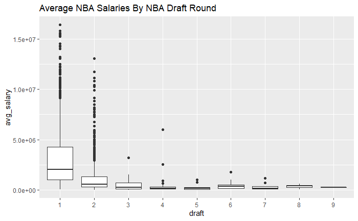

```r
NCAAandNBA %>%
  filter(!is.na(draft)) %>%
  ggplot(aes(x=draft, y=avg_salary)) +
  geom_boxplot() +
  ggtitle("Average NBA Salaries By NBA Draft Round")
```

When making a plot of draft round vs average salary, there does seem to be a strong correlation between draft round and a player’s average salary throughout their career. The median average NBA salary is the highest in the first round, and drops off significantly as it gets to the 3rd round and beyond. This strongly implies that draft round is a good predictor of average salary for a NBA player.

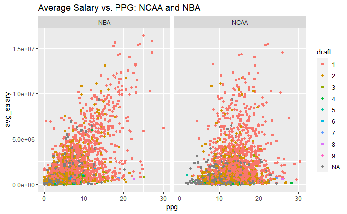

```r
NCAAandNBAppg %>%
  ggplot(aes(x=ppg, y=avg_salary, color = draft)) +
  geom_point() +
  facet_wrap(~leaguePPG) +
  ggtitle("Average Salary vs. PPG: NCAA and NBA")
```

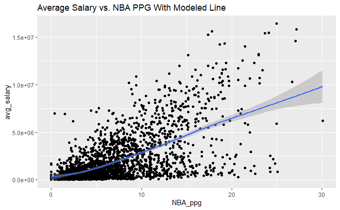

```r
NCAAandNBA %>%
  ggplot(aes(x=NBA_ppg, y=avg_salary))+
  geom_point()+
  geom_smooth() +
  ggtitle("Average Salary vs. NBA PPG With Modeled Line")
```

When including a smoother function into the NBA plot it becomes more apparent that there’s a relativly strong upward trend when comparing ppg to average salary. Based on observations from this plot it’s very likely that NBA ppg is a significant predictor for average salary.

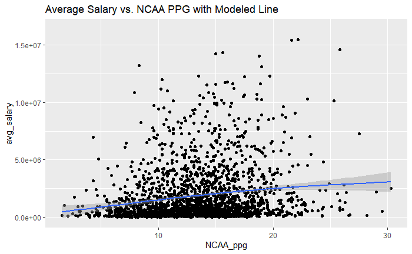

```r
NCAAandNBA %>%
  ggplot(aes(x=NCAA_ppg, y=avg_salary))+
  geom_point()+
  geom_smooth() +
  ggtitle("Average Salary vs. NCAA PPG with Modeled Line")
```

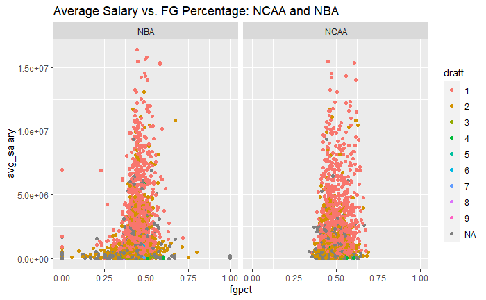

```r
NCAAandNBAfgpct %>%
  ggplot(aes(x=fgpct, y=avg_salary, color = draft)) +
  geom_point() +
  facet_wrap(~leagueFGPCT) +
  ggtitle("Average Salary vs. FG Percentage: NCAA and NBA")
```

In this plot, we can see that for both the NCAA and NBA, average salaries seem to clump into a 0.25 to 0.75 field goal percentage range without any clear trend in the data. For both plots, players seem to earn all ranges of average salaries in very similar field goal percentage ranges. Again, the conclusion about draft round seems to be supported here as well, as we see a higher draft round points to a higher average salary, but doesn’t seem to have much of an effect on field goal percentage in both the NBA and NCAA.

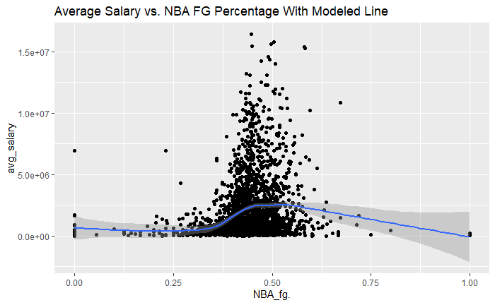

```r
NCAAandNBA %>%
  ggplot(aes(x=NBA_fg., y=avg_salary))+
  geom_point()+
  geom_smooth() +
  ggtitle("Average Salary vs. NBA FG Percentage With Modeled Line")
```

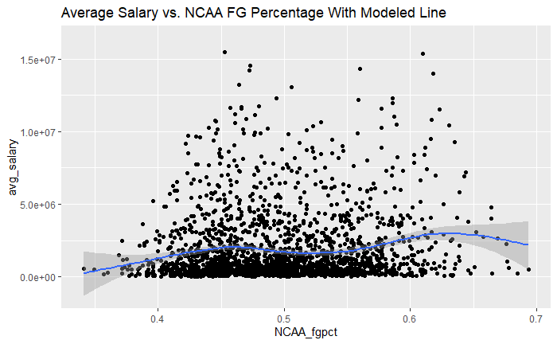

```r
NCAAandNBA %>%
  ggplot(aes(x=NCAA_fgpct, y=avg_salary))+
  geom_point()+
  geom_smooth() +
  ggtitle("Average Salary vs. NCAA FG Percentage With Modeled Line")
```